# Identifying the VIP’s

Eduardo Carrascosa

2/2/2022

### Welcome to this marketing data mining prediction project!

In this exercise, we are asked to “identify” the VIP customers in the decision set of 30,000 customers. Data for the decision set of customers are found in etots_decision.csv. We will do this based on a model that we develop using the data in etots_training.csv, which contains the same type of data for another random sample of 30,000 customers.

We must decide which of the 30,000 customers in the decision set to designate for VIP treatment.

### Discussion Questions

1. Your score would be zero if no one is assigned for VIP treatment (i.e., no incremental revenue and no incremental cost). What would be the score if you designate everyone in the etots training set for VIP treatment? Describe your calculations.
2. Based on the data in the etots training set, what is the value of perfect information (i.e., the difference in scores between designating everyone for VIP treatment vs. designating only those who “deserved” such treatment given their response)? Describe your calculations.
3. Describe the model you used to identify customers for VIP treatment.
   1. Describe the model and your modeling strategy.
   2. What kind of economic analysis did you perform to evaluate your predictive model and select the customers to be assigned to VIP?
   3. What is your projected score? How did you calculate this score?

### Prediction Score

Our decisions will be scored as follows:

- We will be charged $3.25 for each VIP treatment;
- We will receive an incremental revenue of $9.80 from each VIP-treated customer who made a purchase during Holiday 2000 (i.e., HOL_REP = 1).
- Customers receiving regular treatment will not affect your score

The following table summarizes the above rules:

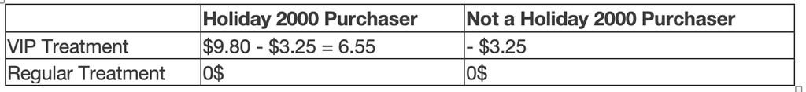

Let’s look at the dataset:

### Read in the data

```r
library(tidyverse)
library(data.table)
library(corrplot)
library(DT)
library(caret)


training_data <- read_csv("/Users/eduardocarrascosa/Desktop/MS-Analytics/Marketing-Analytics/Final/etots_training.csv")
decision_data <- read_csv("/Users/eduardocarrascosa/Desktop/MS-Analytics/Marketing-Analytics/Final/etots_decision.csv")
```

Lets first have a look at these files:

### Peek at the dataset

#### Training set

There are a total of 36 features per customer. You can scroll the x-axis to see all features.

|  | HOL_REP | HOL_MVAL | S_99HOL | M_VAL99H | S_00OFF | M_VAL00O | REC | TENURE | S_IDX | N_S_INDX | Self | Gift | J_9711 | J_9712 | J_9801 | J_9802 | J_9803 | J_9804 | J_9805 | J_9806 | J_9807 | J_9808 | J_9809 | J_9810 | J_9811 | J_9812 | J_9901 | J_9902 | J_9903 | … |
| --- | --- | --- | --- | --- | --- | --- | --- | --- | --- | --- | --- | --- | --- | --- | --- | --- | --- | --- | --- | --- | --- | --- | --- | --- | --- | --- | --- | --- | --- | --- |
| 1 | 0 | 0 | 0 | 0 | 0 | 0 | 21 | 21 | 1 | 0 | 1 | 0 | 0 | 0 | 0 | 0 | 0 | 0 | 0 | 0 | 0 | 0 | 0 | 0 | 0 | 1 | 0 | 0 | 0 | … |
| 2 | 0 | 0 | 0 | 0 | 0 | 0 | 21 | 21 | 1 | 0 | 1 | 0 | 0 | 0 | 0 | 0 | 0 | 0 | 0 | 0 | 0 | 0 | 0 | 0 | 0 | 1 | 0 | 0 | 0 | … |
| 3 | 0 | 0 | 0 | 0 | 0 | 0 | 25 | 25 | 0 | 1 | 0 | 1 | 0 | 0 | 0 | 0 | 0 | 0 | 0 | 0 | 0 | 1 | 0 | 0 | 0 | 0 | 0 | 0 | 0 | … |
| 4 | 0 | 0 | 0 | 0 | 0 | 0 | 21 | 21 | 1 | 0 | 1 | 0 | 0 | 0 | 0 | 0 | 0 | 0 | 0 | 0 | 0 | 0 | 0 | 0 | 0 | 1 | 0 | 0 | 0 | … |
| 5 | 0 | 0 | 661.32 | 661.32 | 0 | 0 | 9 | 21 | 0.5 | 0.5 | 0 | 0 | 0 | 0 | 0 | 0 | 0 | 0 | 0 | 0 | 0 | 0 | 0 | 0 | 0 | 1 | 0 | 0 | 0 | … |
| 6 | 0 | 0 | 0 | 0 | 0 | 0 | 22 | 22 | 1 | 0 | 1 | 0 | 0 | 0 | 0 | 0 | 0 | 0 | 0 | 0 | 0 | 0 | 0 | 0 | 1 | 0 | 0 | 0 | 0 | … |
| 7 | 0 | 0 | 0 | 0 | 0 | 0 | 21 | 21 | 0 | 1 | 0 | 1 | 0 | 0 | 0 | 0 | 0 | 0 | 0 | 0 | 0 | 0 | 0 | 0 | 0 | 1 | 0 | 0 | 0 | … |
| 8 | 0 | 0 | 0 | 0 | 0 | 0 | 22 | 22 | 0 | 1 | 0 | 1 | 0 | 0 | 0 | 0 | 0 | 0 | 0 | 0 | 0 | 0 | 0 | 0 | 1 | 0 | 0 | 0 | 0 | … |
| 9 | 0 | 0 | 73.94 | 73.94 | 0 | 0 | 10 | 15 | 1 | 0 | 1 | 0 | 0 | 0 | 0 | 0 | 0 | 0 | 0 | 0 | 0 | 0 | 0 | 0 | 0 | 0 | 0 | 0 | 0 | … |
| 10 | 0 | 0 | 0 | 0 | 0 | 0 | 13 | 13 | 1 | 0 | 1 | 0 | 0 | 0 | 0 | 0 | 0 | 0 | 0 | 0 | 0 | 0 | 0 | 0 | 0 | 0 | 0 | 0 | 0 | … |

[output cut: 90 more lines]

#### Decision set

|  | ID | S_99HOL | M_VAL99H | S_00OFF | M_VAL00O | REC | TENURE | S_IDX | N_S_INDX | Self | Gift | J_9711 | J_9712 | J_9801 | J_9802 | J_9803 | J_9804 | J_9805 | J_9806 | J_9807 | J_9808 | J_9809 | J_9810 | J_9811 | J_9812 | J_9901 | J_9902 | J_9903 | J_9904 | … |
| --- | --- | --- | --- | --- | --- | --- | --- | --- | --- | --- | --- | --- | --- | --- | --- | --- | --- | --- | --- | --- | --- | --- | --- | --- | --- | --- | --- | --- | --- | --- |
| 1 | 1 | 0 | 0 | 0 | 0 | 19 | 19 | 1 | 0 | 1 | 0 | 0 | 0 | 0 | 0 | 0 | 0 | 0 | 0 | 0 | 0 | 0 | 0 | 0 | 0 | 0 | 1 | 0 | 0 | … |
| 2 | 2 | 0 | 0 | 0 | 0 | 22 | 22 | 1 | 0 | 1 | 0 | 0 | 0 | 0 | 0 | 0 | 0 | 0 | 0 | 0 | 0 | 0 | 0 | 1 | 0 | 0 | 0 | 0 | 0 | … |
| 3 | 3 | 0 | 0 | 0 | 0 | 14 | 14 | 1 | 0 | 1 | 0 | 0 | 0 | 0 | 0 | 0 | 0 | 0 | 0 | 0 | 0 | 0 | 0 | 0 | 0 | 0 | 0 | 0 | 0 | … |
| 4 | 4 | 73.78 | 73.78 | 0 | 0 | 11 | 13 | 0 | 1 | 0 | 1 | 0 | 0 | 0 | 0 | 0 | 0 | 0 | 0 | 0 | 0 | 0 | 0 | 0 | 0 | 0 | 0 | 0 | 0 | … |
| 5 | 5 | 90.29 | 90.29 | 40.82 | 40.82 | 6 | 19 | 1 | 0 | 1 | 0 | 0 | 0 | 0 | 0 | 0 | 0 | 0 | 0 | 0 | 0 | 0 | 0 | 0 | 0 | 0 | 1 | 0 | 0 | … |
| 6 | 6 | 42.0525 | 168.21 | 31.39666667 | 94.19 | 0 | 22 | 0.526315789 | 0.473684211 | 0 | 0 | 0 | 0 | 0 | 0 | 0 | 0 | 0 | 0 | 0 | 0 | 0 | 0 | 1 | 0 | 0 | 0 | 0 | 0 | … |
| 7 | 7 | 52.27 | 104.54 | 0 | 0 | 9 | 21 | 0.571428571 | 0.428571429 | 0 | 0 | 0 | 0 | 0 | 0 | 0 | 0 | 0 | 0 | 0 | 0 | 0 | 0 | 0 | 1 | 0 | 0 | 0 | 0 | … |
| 8 | 8 | 0 | 0 | 0 | 0 | 21 | 21 | 1 | 0 | 1 | 0 | 0 | 0 | 0 | 0 | 0 | 0 | 0 | 0 | 0 | 0 | 0 | 0 | 0 | 1 | 0 | 0 | 0 | 0 | … |
| 9 | 9 | 0 | 0 | 0 | 0 | 22 | 22 | 1 | 0 | 1 | 0 | 0 | 0 | 0 | 0 | 0 | 0 | 0 | 0 | 0 | 0 | 0 | 0 | 1 | 0 | 0 | 0 | 0 | 0 | … |
| 10 | 10 | 0 | 0 | 0 | 0 | 21 | 21 | 0 | 1 | 0 | 1 | 0 | 0 | 0 | 0 | 0 | 0 | 0 | 0 | 0 | 0 | 0 | 0 | 0 | 1 | 0 | 0 | 0 | 0 | … |

[output cut: 90 more lines]

### Renaming the features

```r
  training_data <- training_data %>%
  rename(
    holiday_2020_purchase = HOL_REP,
    holiday_2020_total_spend = HOL_MVAL,
    holiday_2019_average_order_size = S_99HOL,
    holiday_2019_total_spend = M_VAL99H,
    offseason_2020_average_order_size = S_00OFF,
    offseason_2020_total_spend = M_VAL00O,
    recency = REC,
    tenure = TENURE,
    self_index =  S_IDX,
    not_self_index = N_S_INDX,
    nov_2007 = J_9711,
    dec_2007 = J_9712,
    jan_2008 = J_9801,
    feb_2008 = J_9802,
    mar_2008 = J_9803,
    apr_2008 = J_9804,
    may_2008 =J_9805,
    jun_2008 = J_9806,
    jul_2008 = J_9807,
    aug_2008 = J_9808,
    sep_2008 = J_9809,
    oct_2008 = J_9810,
    nov_2008 = J_9811,
    dec_2008 = J_9812,
    jan_2009 = J_9901,
    feb_2009 = J_9902,
    mar_2009 = J_9903,
    apr_2009 = J_9904,
    may_2009 = J_9905,
    jun_2009 = J_9906,
    jul_2009 = J_9907,
    aug_2009 = J_9908,
    sep_2009 = J_9909

  )
```

### Peek at the renamed dataset

#### Training data

Much better :-). You can scroll the x-axis to see all features.

|  | holiday_2020_purchase | holiday_2020_total_spend | holiday_2019_average_order_size | holiday_2019_total_spend | offseason_2020_average_order_size | offseason_2020_total_spend | recency | tenure | self_index | not_self_index | Self | Gift | nov_2007 | dec_2007 | jan_2008 | feb_2008 | mar_2008 | apr_2008 | may_2008 | jun_2008 | jul_2008 | aug_2008 | sep_2008 | oct_2008 | nov_2008 | dec_2008 | jan_2009 | feb_2009 | mar_2009 | … |
| --- | --- | --- | --- | --- | --- | --- | --- | --- | --- | --- | --- | --- | --- | --- | --- | --- | --- | --- | --- | --- | --- | --- | --- | --- | --- | --- | --- | --- | --- | --- |
| 1 | 0 | 0 | 0 | 0 | 0 | 0 | 21 | 21 | 1 | 0 | 1 | 0 | 0 | 0 | 0 | 0 | 0 | 0 | 0 | 0 | 0 | 0 | 0 | 0 | 0 | 1 | 0 | 0 | 0 | … |
| 2 | 0 | 0 | 0 | 0 | 0 | 0 | 21 | 21 | 1 | 0 | 1 | 0 | 0 | 0 | 0 | 0 | 0 | 0 | 0 | 0 | 0 | 0 | 0 | 0 | 0 | 1 | 0 | 0 | 0 | … |
| 3 | 0 | 0 | 0 | 0 | 0 | 0 | 25 | 25 | 0 | 1 | 0 | 1 | 0 | 0 | 0 | 0 | 0 | 0 | 0 | 0 | 0 | 1 | 0 | 0 | 0 | 0 | 0 | 0 | 0 | … |
| 4 | 0 | 0 | 0 | 0 | 0 | 0 | 21 | 21 | 1 | 0 | 1 | 0 | 0 | 0 | 0 | 0 | 0 | 0 | 0 | 0 | 0 | 0 | 0 | 0 | 0 | 1 | 0 | 0 | 0 | … |
| 5 | 0 | 0 | 661.32 | 661.32 | 0 | 0 | 9 | 21 | 0.5 | 0.5 | 0 | 0 | 0 | 0 | 0 | 0 | 0 | 0 | 0 | 0 | 0 | 0 | 0 | 0 | 0 | 1 | 0 | 0 | 0 | … |
| 6 | 0 | 0 | 0 | 0 | 0 | 0 | 22 | 22 | 1 | 0 | 1 | 0 | 0 | 0 | 0 | 0 | 0 | 0 | 0 | 0 | 0 | 0 | 0 | 0 | 1 | 0 | 0 | 0 | 0 | … |
| 7 | 0 | 0 | 0 | 0 | 0 | 0 | 21 | 21 | 0 | 1 | 0 | 1 | 0 | 0 | 0 | 0 | 0 | 0 | 0 | 0 | 0 | 0 | 0 | 0 | 0 | 1 | 0 | 0 | 0 | … |
| 8 | 0 | 0 | 0 | 0 | 0 | 0 | 22 | 22 | 0 | 1 | 0 | 1 | 0 | 0 | 0 | 0 | 0 | 0 | 0 | 0 | 0 | 0 | 0 | 0 | 1 | 0 | 0 | 0 | 0 | … |
| 9 | 0 | 0 | 73.94 | 73.94 | 0 | 0 | 10 | 15 | 1 | 0 | 1 | 0 | 0 | 0 | 0 | 0 | 0 | 0 | 0 | 0 | 0 | 0 | 0 | 0 | 0 | 0 | 0 | 0 | 0 | … |
| 10 | 0 | 0 | 0 | 0 | 0 | 0 | 13 | 13 | 1 | 0 | 1 | 0 | 0 | 0 | 0 | 0 | 0 | 0 | 0 | 0 | 0 | 0 | 0 | 0 | 0 | 0 | 0 | 0 | 0 | … |

[output cut: 90 more lines]

### Data Cleaning

Gift and Self have missing data, lets fill with zero.

```r
colSums(is.na(training_data))

training_data <-
  mutate(training_data, Missing_Self = is.na(Self), Missing_Gift = is.na(Gift)) %>%
  replace_na(list(Self = 0, Gift = 0))
```

[output not shown]

The holiday_2020_total_spend variable is not available in the decision set so lets remove it from the training data and create the target variable.

```r
training_data <- training_data %>%
    select(-holiday_2020_total_spend)
```

How many customer rows in the data?

```r
n <- nrow(training_data)
n
```

```
## [1] 30000
```

### Feature Engineering

Check if the target variable is balanced - minority class is about 33% of the dataset, mildly imbalanced.

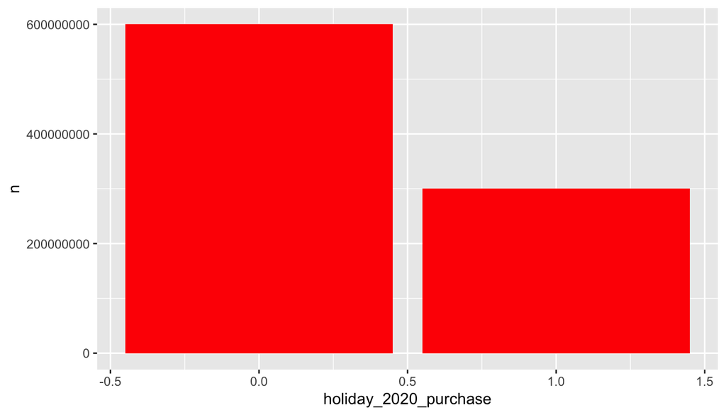

```r
training_data %>%
  group_by(holiday_2020_purchase) %>%
  ggplot(aes(x = holiday_2020_purchase, y = n)) +
  geom_bar(stat = "identity", fill = "red")
```

### Create the target variable

```r
target <- factor(training_data$holiday_2020_purchase)
```

### Partition the data according to the following ratios

```r
training_p <- 0.2
validation_p <- 0.35
validation_size <- validation_p * n

set.seed(909439224)
all_rows = 1:n
training_index <- createDataPartition(target, p = training_p, list=TRUE)$Resample1
validation_index <- sample(setdiff(n, training_index), size = validation_size)
test_index <- setdiff(setdiff(all_rows, training_index), validation_index)
```

### Let’s create a training index with a balanced outcome variable

```r
training_downsample <- downSample(training_index, target[training_index], list = FALSE)$x
training_upsample <- upSample(training_index, target[training_index], list = FALSE)$x
```

The target variable is now balanced with equal representation of buyers and non-buyers.

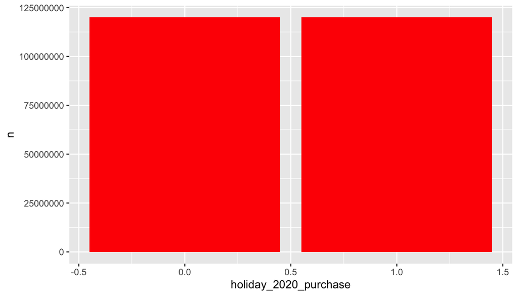

```r
training_data %>%
  slice(training_upsample) %>%
  ggplot(aes(x = holiday_2020_purchase, y = n)) +
  geom_bar(stat="identity", fill = "red")
```

### Normalize the data

```r
trainig_data <- training_data %>% mutate(
holiday_2019_average_order_size = scale(holiday_2019_average_order_size),
holiday_2019_total_spend = scale(holiday_2019_total_spend),
offseason_2020_average_order_size = scale(offseason_2020_average_order_size),
offseason_2020_total_spend = scale(offseason_2020_total_spend),
recency = scale(recency),
tenure = scale(tenure),
self_index = factor(self_index),
not_self_index = factor(not_self_index),
nov_2007 = factor(nov_2007),
dec_2007 = factor(dec_2007),
jan_2008 = factor(jan_2008),
feb_2008 = factor(feb_2008),
mar_2008 = factor(mar_2008),
apr_2008 = factor(apr_2008),
may_2008 = factor(may_2008),
jun_2008 = factor(jun_2008),
jul_2008 = factor(jul_2008),
aug_2008 = factor(aug_2008),
sep_2008 = factor(sep_2008),
oct_2008 = factor(oct_2008),
nov_2008 = factor(nov_2008),
dec_2008 = factor(dec_2008),
jan_2009 = factor(jan_2009),
feb_2009 = factor(feb_2009),
mar_2009 = factor(mar_2009),
apr_2009 = factor(apr_2009),
may_2009 = factor(may_2009),
jun_2009 = factor(jun_2009),
jul_2009 = factor(jul_2009),
aug_2009 = factor(aug_2009),
sep_2009 = factor(sep_2009)
)
```

## Model development stage

At this stage we will not use “test set”. We will try different models and decide which one is better. After trying different models we will settle on one.

### Model 1: Classification Tree

```r
model_1 <- train(
  factor(holiday_2020_purchase) ~.,
  data = training_data[training_downsample, ],
  method = 'rpart'
)

score_validation <- predict(model_1, newdata = training_data[validation_index, ])

confusionMatrix(score_validation, target[validation_index], positive="1")
```

```
## Confusion Matrix and Statistics
##
##           Reference
## Prediction    0    1
##          0 5204  888
##          1 1780 2628
##
##                Accuracy : 0.7459
##                  95% CI : (0.7375, 0.7542)
##     No Information Rate : 0.6651
##     P-Value [Acc > NIR] : < 0.00000000000000022
##
##                   Kappa : 0.4634
##
##  Mcnemar's Test P-Value : < 0.00000000000000022
##
##             Sensitivity : 0.7474
##             Specificity : 0.7451
##          Pos Pred Value : 0.5962
##          Neg Pred Value : 0.8542
##              Prevalence : 0.3349
##          Detection Rate : 0.2503
##    Detection Prevalence : 0.4198
##       Balanced Accuracy : 0.7463
##
##        'Positive' Class : 1
##
```

### Model 2: Random Forest

```r
model_2 <- train(
  factor(holiday_2020_purchase) ~ .,
  data = training_data[training_downsample, ],
  method = 'rf'
)

score_validation <- predict(model_2, newdata = training_data[validation_index, ])

confusionMatrix(score_validation, target[validation_index], positive="1")
```

```
## Confusion Matrix and Statistics
##
##           Reference
## Prediction    0    1
##          0 5224  899
##          1 1760 2617
##
##                Accuracy : 0.7468
##                  95% CI : (0.7383, 0.7551)
##     No Information Rate : 0.6651
##     P-Value [Acc > NIR] : < 0.00000000000000022
##
##                   Kappa : 0.4641
##
##  Mcnemar's Test P-Value : < 0.00000000000000022
##
##             Sensitivity : 0.7443
##             Specificity : 0.7480
##          Pos Pred Value : 0.5979
##          Neg Pred Value : 0.8532
##              Prevalence : 0.3349
##          Detection Rate : 0.2492
##    Detection Prevalence : 0.4169
##       Balanced Accuracy : 0.7462
##
##        'Positive' Class : 1
##
```

### Model 3: Gradient Boosting

```r
model_3 <- train(
  factor(holiday_2020_purchase) ~ .,
  data = training_data[training_downsample, ],
  method = 'xgbTree',
  verbosity = 0
)


score_validation <- predict(model_3, newdata = training_data[validation_index, ])

confusionMatrix(score_validation, target[validation_index], positive="1")
```

```
## Confusion Matrix and Statistics
##
##           Reference
## Prediction    0    1
##          0 5211  896
##          1 1773 2620
##
##                Accuracy : 0.7458
##                  95% CI : (0.7374, 0.7541)
##     No Information Rate : 0.6651
##     P-Value [Acc > NIR] : < 0.00000000000000022
##
##                   Kappa : 0.4626
##
##  Mcnemar's Test P-Value : < 0.00000000000000022
##
##             Sensitivity : 0.7452
##             Specificity : 0.7461
##          Pos Pred Value : 0.5964
##          Neg Pred Value : 0.8533
##              Prevalence : 0.3349
##          Detection Rate : 0.2495
##    Detection Prevalence : 0.4184
##       Balanced Accuracy : 0.7456
##
##        'Positive' Class : 1
##
```

## Evaluation stage

```r
score_test <- predict(model_3, newdata = training_data[test_index, ])

confusionMatrix(score_test, target[test_index], positive="1")
```

```
## Confusion Matrix and Statistics
##
##           Reference
## Prediction    0    1
##          0 7809 1405
##          1 2558 3806
##
##                Accuracy : 0.7456
##                  95% CI : (0.7387, 0.7524)
##     No Information Rate : 0.6655
##     P-Value [Acc > NIR] : < 0.00000000000000022
##
##                   Kappa : 0.4584
##
##  Mcnemar's Test P-Value : < 0.00000000000000022
##
##             Sensitivity : 0.7304
##             Specificity : 0.7533
##          Pos Pred Value : 0.5981
##          Neg Pred Value : 0.8475
##              Prevalence : 0.3345
##          Detection Rate : 0.2443
##    Detection Prevalence : 0.4085
##       Balanced Accuracy : 0.7418
##
##        'Positive' Class : 1
##
```